# ex_cosmo_query

General imports

```python
import numpy as np
import matplotlib.pyplot as plt
%matplotlib inline
```

Specific imports

```python
from COSMO_query import config, SSH, Query
from COSMO_query import save_netcdf, load_netcdf
from COSMO_query import extract, coords_profile
```

# 1. Establishing connection with CSCS servers

First step is to establish a connection to CSCS servers, this connection can then be used to retrieved COSMO data

We initiate a connection to ela.cscs.ch, with username and password specified in the *config.py* file (password is not needed if ssh key is defined)

```python
connection = SSH(config.ELA_ADRESS,config.USERNAME,config.PASSWORD)
```

```
Connecting to server...
```

We also need to open a channel to kesch.cscs.ch since *field_extra* (the tool that is used to extract and convert from Grib files) is not available on ela.cscs.ch

```python
connection.open_channel(config.KESCH_ADRESS,config.USERNAME)
```

# 2. Retrieving COSMO data

Now that the connection is setup we can create a Query instance

```python
query = Query(connection)
```

And use this query to retrieve some data

```python
variables = ['T','P'] # we want temperature and pressure, see next cell to know which variables you can get
date = '2016-05-31 12:30' # for the 31th May 2016 at 12h30
model_res = 'fine' # at high resolution (COSMO-2 in this case)
mode = 'analysis' # In analysis mode
coord_bounds = ([6.6,45.8],[8.4,46.6]) # Over an area covering roughly the Valais

data = query.retrieve_data(variables, date, model_res = 'fine',
                          mode = 'analysis', coord_bounds = coord_bounds)
```

```
Output will be written to '/users/wolfensb/PMSL.grb'.

Extracting table of content...

Filtering...

Output will be written to '/users/wolfensb/PMSL_cosmo_2.nc'.

Extracting table of content...

Converting to NETCDF...

(163, 233, 136, 187)
Output will be written to '/users/wolfensb/filtered0.grb'.
Extracting table of content...

Filtering...

Output will be written to '/users/wolfensb/crop0.grb'.

Extracting table of content...

Cropping...

Output will be written to '/users/wolfensb/convert0.nc'.

Extracting table of content...

Converting to NETCDF...

Output will be written to '/users/wolfensb/filtered1.grb'.

Extracting table of content...

Filtering...

Output will be written to '/users/wolfensb/crop1.grb'.

Extracting table of content...

Cropping...

Output will be written to '/users/wolfensb/convert1.nc'.

Extracting table of content...

Converting to NETCDF...
```

To know which variables are in the file, you can either check the file logs in your path_to_library/cosmo_info/file_logs/ folder or you can use the function *get_available_vars*

```python
print(query.get_available_vars(date = '2016-05-31 12:30', model_res = 'fine', mode = 'analysis'))
```

# 3. Saving/Loading data

We can save this data to a netcdf

```python
save_netcdf(data,'myfile.nc')
```

And load it again from this file

```python
data = load_netcdf('myfile.nc')
```

# 4. Extracting profiles

We can then use this data to extract a profile, here are some examples

### 4.1 Profile at fixed vertical levels (altitudes)

```python
prof1 = extract(data,['T'],'level',[2000,4000])
```

```python
prof1['T'].coordinates.keys()
```

```
['heights', 'lat', 'lon']
```

### 4.2 Latitudinal profile

Here we get the profile of pressure and temperature at 46.2 degrees latitude

```python
prof2 = extract(data,['P','T'],'lat',46.2)
```

The output is a dictionary, with two keys 'T' and 'P' (which corresponds to the variables you wanted). In this case the coordinates are:

```python
prof2['T'].coordinates.keys()
```

```
['heights', 'lon/lat']
```

Where *heights* is an $M \times N$ array of model heights, with $N$ being the length of the profile and $M$ being the number of vertical models of the model. *lon/lat* is a $N \times 2$ array of lon,lat coordinates.

### 4.3 Longitudinal profile

```python
prof3 = extract(data,['T'],'lon',7)
```

### 4.4 Arbitrary lon/lat transect

We can also get a transect (vert. profile) through an arbitrary set of lon/lat coordinates. If you want a rectilinear profile you can use the *coords_profile* function

```python
# Transect going from Martigny to Visp with a step of 2000 m
coords = coords_profile([7.07,46.1],[7.88,46.29],step=2000)
# or transect going from Martigny to Visp with 100 equidistant points
coords2 = coords_profile([7.07,46.1],[7.88,46.29],npts = 100)
```

Output is a $N \times 2$ array of lon/lat coordinates

If wou want a non-rectilinear profile, you will have to construct your $N \times 2$ array of coordinates yourself...

```python
prof3 = extract(data,['T'],'lonlat',coords)
```

Coordinates are the same as for *lat* and *lon* profiles. Besides *coordinates* the outputs arrays have an additional variable called *attributes* which contains additional useful info. In this case there is only one attribute *distance* which gives the distance along the profile.

### 4.5 PPI profiles

It is also possible to simulate PPI profiles from a radar, to do this you need to provide a dictionary with the necessary parameters (mandatory ones are in *bold*)

- **beamwidth** : 3dB beamwidth of the radar (in degrees)
- **elevation** : elevation angle of the PPI (in degrees)
- **rrange** : 1D array containing the distance of all radar gates
- **rpos** : position of the radar in the form [lon,lat,altitude]
- *azimuth* : 1D array containing all azimuth angles in the scan. Default is from 0 to 360 with a step corresponding to the 3dB beamwidth.
- *npts_quad* : tuple of the form [npts_hor, npts_ver], the interpolation scheme uses a quadrature scheme to interpolate over the antenna diagram. This defines the number of integration points in horizontal and vertical directions. Use [1,1] if you want no integration. Default is [3,3]
- *refraction_method* : To compute the propagation of the radar beam, two schemes can be used: if refraction_scheme = 1, the standard 4/3 Earth radius scheme will be used, if refraction_scheme = 2, a more accurate scheme based on a refractivity profile estimated from the model will be used; this requires QV (water vapour), T (temperature) and P (pressure) to be present in the file. Default is 1

In the example below we simulate a PPI scan at 10 degree elevation in Martigny

```python
options_PPI = {}
options_PPI['beamwidth'] = 1.5 # 1.5 deg 3dB beamwidth, as MXPol
options_PPI['elevation'] = 10
options_PPI['rrange'] = np.arange(200,20000,75) # from 0.2 to 20 km with a res of 75 m
options_PPI['npts_quad'] = [3,3] # 3 quadrature points in azimuthal, 3 in elevational directions
options_PPI['rpos'] = [7.0923,46.1134,500] # Radar position in lon/lat/alt
options_PPI['refraction_method'] = 1 # 1 = standard 4/3, 2 = ODE refraction

ppi_T = extract(data,['T'],'PPI',options_PPI)
```

```
            Could not read 'azimuth' field in input dict.
            Using default one: np.arange(0,360,beamwidth_3dB)


            Could not read 'refraction_method' field in input dict.
            Using default one: 1 (4/3 Earth radius method)

Processing azimuth ang. 0.0
Processing azimuth ang. 1.5
Processing azimuth ang. 3.0
Processing azimuth ang. 4.5
Processing azimuth ang. 6.0
Processing azimuth ang. 7.5
Processing azimuth ang. 9.0
Processing azimuth ang. 10.5
Processing azimuth ang. 12.0
Processing azimuth ang. 13.5
Processing azimuth ang. 15.0
Processing azimuth ang. 16.5
Processing azimuth ang. 18.0
Processing azimuth ang. 19.5
Processing azimuth ang. 21.0
Processing azimuth ang. 22.5
Processing azimuth ang. 24.0
Processing azimuth ang. 25.5
Processing azimuth ang. 27.0
Processing azimuth ang. 28.5
Processing azimuth ang. 30.0
Processing azimuth ang. 31.5
Processing azimuth ang. 33.0
Processing azimuth ang. 34.5
Processing azimuth ang. 36.0
Processing azimuth ang. 37.5
Processing azimuth ang. 39.0
Processing azimuth ang. 40.5
Processing azimuth ang. 42.0
Processing azimuth ang. 43.5
Processing azimuth ang. 45.0
Processing azimuth ang. 46.5
Processing azimuth ang. 48.0
```

[output cut: 193 more lines]

```
Processing azimuth ang. 339.0
Processing azimuth ang. 340.5
Processing azimuth ang. 342.0
Processing azimuth ang. 343.5
Processing azimuth ang. 345.0
Processing azimuth ang. 346.5
Processing azimuth ang. 348.0
Processing azimuth ang. 349.5
Processing azimuth ang. 351.0
Processing azimuth ang. 352.5
Processing azimuth ang. 354.0
Processing azimuth ang. 355.5
Processing azimuth ang. 357.0
Processing azimuth ang. 358.5
Processing azimuth ang. 360.0
```

Output is in polar coordinates with coordinates = *rrange*, *azimuth*

```python
print(ppi_T['T'].coordinates.keys())
```

```
['rrange', 'azimuth']
```

Its attributes are the *height* of the radar gates (altitude), their *lon* and *lat*, the *elevation* angle as well as the *frac_power* of every radar gate which indicates which fraction of the incident power reached the radar gate. 0 means that all the signal was lost (i.e. complete beam-blockage), 1 means that no signal was lost.

```python
print(ppi_T['T'].attributes.keys())
```

```
['heights', 'lon', 'lat', 'elevation', 'frac_power']
```

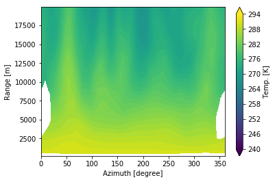

```python
plt.contourf(ppi_T['T'].coordinates['azimuth'],ppi_T['T'].coordinates['rrange'],ppi_T['T'],
             levels = np.arange(240,295,1),extend='both')
plt.colorbar(label = 'Temp. [K]')
plt.xlabel('Azimuth [degree]')
plt.ylabel('Range [m]')
```

Missing areas (white pixels) correspond to areas with total beam blockage

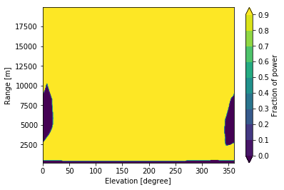

```python
plt.contourf(ppi_T['T'].coordinates['azimuth'],ppi_T['T'].coordinates['rrange'],
             ppi_T['T'].attributes['frac_power'],levels = np.arange(0,1,0.1),extend='both')
plt.colorbar(label = 'Fraction of power')
plt.xlabel('Elevation [degree]')
plt.ylabel('Range [m]')
```

Note that the COSMO DEM is quite imprecise, so the topography of COSMO might be higher than the real topography...for example real altitude of this point is 458.2 but closest COSMO point is at 626.28 m altitude...

### 4.6 RHI profiles

It is also possible to simulate RHI profiles from a radar. The outputs are exactly the same as for PPI except that the *elevation* argument is now an optional list (with a default of 0 to 90 with a step corresponding to the 3dB beamwidth) and that the *azimuth* argument is a mandatory scalar.

Below we simulate a RHI scan from Martigny with an azimuth angle of 47 degrees corresponding to the direction of the valley.

```python
options_RHI = {}
options_RHI['beamwidth'] = 1.5 # 1.5 deg 3dB beamwidth, as MXPol
options_RHI['azimuth'] = 47
options_RHI['rrange'] = np.arange(200,10000,75) # from 0.2 to 10 km with a res of 75 m
options_RHI['npts_quad'] = [3,3] # 3 quadrature points in azimuthal, 3 in elevational directions
options_RHI['rpos'] = [7.0923,46.1134,500] # Radar position in lon/lat/alt
options_RHI['refraction_method'] = 1 # 1 = standard 4/3, 2 = ODE refraction

rhi_T = extract(data,['T'],'RHI',options_RHI)
```

```
            Could not read 'elevation' field in input dict.
            Using default one: np.arange(0,90,beamwidth_3dB)

Processing elevations ang. 0.0
Processing elevations ang. 1.5
Processing elevations ang. 3.0
Processing elevations ang. 4.5
Processing elevations ang. 6.0
Processing elevations ang. 7.5
Processing elevations ang. 9.0
Processing elevations ang. 10.5
Processing elevations ang. 12.0
Processing elevations ang. 13.5
Processing elevations ang. 15.0
Processing elevations ang. 16.5
Processing elevations ang. 18.0
Processing elevations ang. 19.5
Processing elevations ang. 21.0
Processing elevations ang. 22.5
Processing elevations ang. 24.0
Processing elevations ang. 25.5
Processing elevations ang. 27.0
Processing elevations ang. 28.5
Processing elevations ang. 30.0
Processing elevations ang. 31.5
Processing elevations ang. 33.0
Processing elevations ang. 34.5
Processing elevations ang. 36.0
Processing elevations ang. 37.5
Processing elevations ang. 39.0
Processing elevations ang. 40.5
Processing elevations ang. 42.0
Processing elevations ang. 43.5
Processing elevations ang. 45.0
Processing elevations ang. 46.5
Processing elevations ang. 48.0
Processing elevations ang. 49.5
Processing elevations ang. 51.0
Processing elevations ang. 52.5
Processing elevations ang. 54.0
```

[output cut: 9 more lines]

```
Processing elevations ang. 69.0
Processing elevations ang. 70.5
Processing elevations ang. 72.0
Processing elevations ang. 73.5
Processing elevations ang. 75.0
Processing elevations ang. 76.5
Processing elevations ang. 78.0
Processing elevations ang. 79.5
Processing elevations ang. 81.0
Processing elevations ang. 82.5
Processing elevations ang. 84.0
Processing elevations ang. 85.5
Processing elevations ang. 87.0
Processing elevations ang. 88.5
Processing elevations ang. 90.0
```

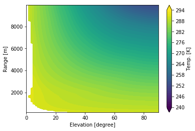

```python
plt.contourf(rhi_T['T'].coordinates['elevation'],rhi_T['T'].coordinates['rrange'],rhi_T['T'],
             levels = np.arange(240,295,1),extend='both')
plt.colorbar(label = 'Temp. [K]')
plt.xlabel('Elevation [degree]')
plt.ylabel('Range [m]')
```